# g1a3-p1_04.06_8pm_edits

## Project 1

Authors: Jonathan Ashbeck, Kelly Lake, Audrey Moore, Laura Sikes, Tommy Steele, & Ecil Teodoro  
Class: STA6349  
Group: 1  
Instructor: Dr. Samantha Seals  
Date: April 7, 2025

## Project 1 Formal Hypotheses

- The average count of bald eagles for 1981-1999 is 0.8. We believe the rate of bald eagle sightings has increased over the years 2000-2017.
- $H_0: \lambda_1 \leq 0.8$
- $H_1: \lambda_1 > 0.8$

## Defining the Prior

- We will be using the posterior from assignment 3 as our new prior, thus, $\lambda \sim \text{Gamma}(18, 19.75)$

```
Alpha Posterior _81_99:  18
```

```
Beta Posterior _81_99:  19.75
```

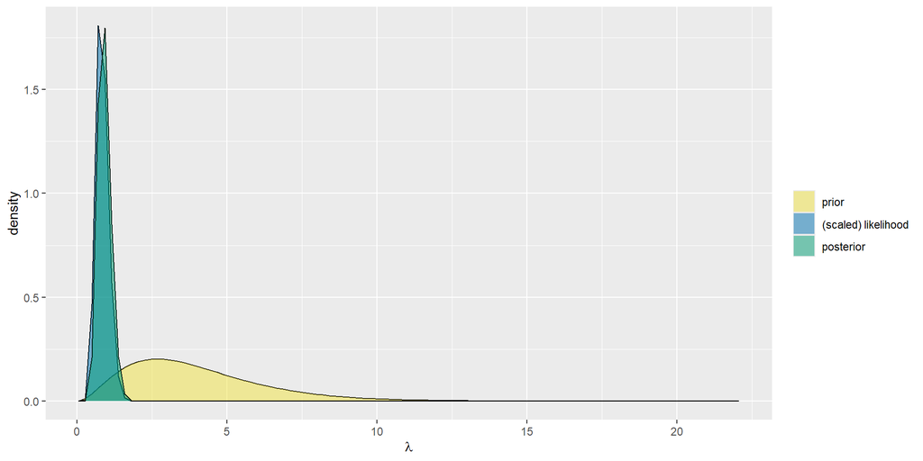

## Derive the Posterior

- From 2000-2017 there were 18 data points with 89 observed eagle sightings.
- We see that $\lambda | \vec{y} \sim \text{Gamma}(107, 37.75)$

```
Alpha Posterior 00-17:  107
```

```
Beta Posterior 00-17:  37.75
```

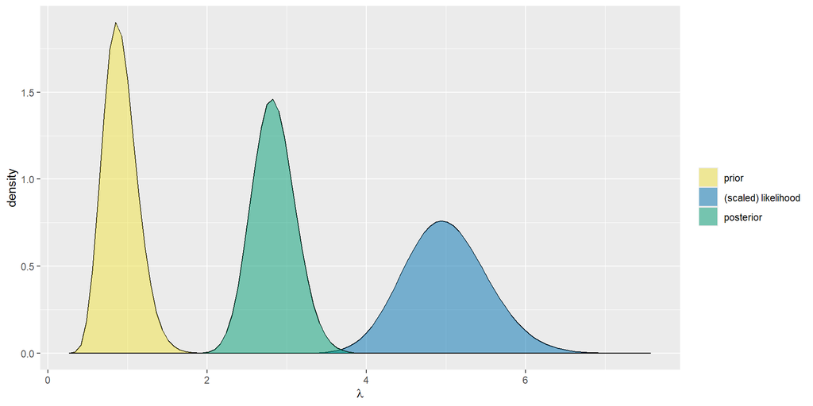

## Middle 95% Credible Interval for Hyperparameter of Interest

- There is a 95% posterior probability that the number of bald eagle sightings per year is between 2.32 and 3.40.

```
95% credible interval for λ: 2.32 3.4
```

## Prior and Posterior Probabilities of Hypotheses

```
[1] "Prior Probability (λ₁ > 0.8): 0.6779"
```

```
[1] "Posterior Probability (λ2 > 0.8): 1"
```

- There is approximately an 67.8% prior chance that bald eagle sightings are higher than 0.8 per year.
- There is essentially a 100% posterior chance that bald eagle sightings are higher than 0.8 per year.

[output not shown]

## Bayes Factor

- Bayes Factor: $2.39\times10^{26}$
- This *very large* Bayes Factor indicates the data overwhelmingly support the alternative hypothesis

```
[1] 2.391142e+26
```

## Summary of Analyses

- Our data overwhelmingly support the alternative hypothesis that the rate of bald eagle sightings has increased over the years 2000-2017 to be greater than 0.8 sightings per year.
- We estimate with 95% confidence that further analysis should begin with a prior value 2.32 to 3.40 sightings per year.
- Our Bayes factor of $2.39\times10^{26}$ is massive. Our 95% CI of 2.32-3.40 sightings is much higher than our prior of 0.8 sightings per year. It makes sense that a difference of this magnitude would be incredibly large when measured in terms of probability as the Bayes factor does.

## Summary of Groupmate Contributions

- Jonathan Ashbeck: 04/02 Team Classwork (hypotheses, new prior, new posterior, 95% CI)
- Kelly Lake: Summary analysis, reviewed null/alternative
- Audrey Moore: Simplified hypothesis; reviewed team work done in class and added additional context/framing to prior, posterior, CI; calculated prior and posterior probabilities; calculated Bayes factor
- Laura Sikes: 04/02 Team Classwork (hypotheses, new prior, new posterior, 95% CI)
- Tommy Steele: 04/02 Team Classwork (hypotheses, new prior, new posterior, 95% CI)
- Ecil Teodoro: 04/02 Team Classwork (hypotheses, new prior, new posterior, 95% CI)